# Question 7

What impact of COVID-19 can be seen on the number of flights in 2021, in comparisson to both 2019 and 2020.

```python
import pandas as pd
import matplotlib.pyplot as plt
import numpy as np
import plotly.express as px
```

Flights data:

```python
#Rome
datarome2019 = pd.read_csv('ROME2019.csv')
datarome2020 = pd.read_csv('ROME2020.csv')
datarome2021 = pd.read_csv('ROME2021.csv')
```

```python
#Milan
datamilan2019 = pd.read_csv('MILAN2019.csv')
datamilan2020 = pd.read_csv('MILAN2020.csv')
datamilan2021 = pd.read_csv('MILAN2021.csv')
```

```python
#Venice
datavenice2019 = pd.read_csv('VENICE2019.csv')
datavenice2020 = pd.read_csv('VENICE2020.csv')
datavenice2021 = pd.read_csv('VENICE2021.csv')
```

```python
#Bologna
databologna2019 = pd.read_csv('BOLOGNA2019.csv')
databologna2020 = pd.read_csv('BOLOGNA2020.csv')
databologna2021 = pd.read_csv('BOLOGNA2021.csv')
```

```python
#Bergamo
databergamo2019 = pd.read_csv('BERGAMO2019.csv')
databergamo2020 = pd.read_csv('BERGAMO2020.csv')
databergamo2021 = pd.read_csv('BERGAMO2021.csv')
```

```python
# Data to plot

romelen = [len(datarome2019), len(datarome2020), len(datarome2021)]
milanlen = [len(datamilan2019), len(datamilan2020), len(datamilan2021)]
venicelen = [len(datavenice2019), len(datavenice2020), len(datavenice2021)]
bolognalen = [len(databologna2019), len(databologna2020), len(databologna2021)]
bergamolen = [len(databergamo2019), len(databergamo2020), len(databergamo2021)]

date = ['7/2019', '7/2020', '7/2021']

#Save the data in an array

dataflights = [[date[0], romelen[0], milanlen[0], venicelen[0], bolognalen[0], bergamolen[0]], [date[1], romelen[1], milanlen[1], venicelen[1], bolognalen[1], bergamolen[1]], [date[2], romelen[2], milanlen[2], venicelen[2], bolognalen[2], bergamolen[2]]]

# Create a data frame

df0 = pd.DataFrame(dataflights, columns=['Date', 'Rome', 'Milan', 'Venice', 'Bologna', 'Bergamo'])
df0.head()
```

|  | Date | Rome | Milan | Venice | Bologna | Bergamo |
| --- | --- | --- | --- | --- | --- | --- |
| 0 | 7/2019 | 14491 | 8175 | 3284 | 2580 | 4387 |
| 1 | 7/2020 | 3753 | 4382 | 1526 | 1196 | 1761 |
| 2 | 7/2021 | 6151 | 6495 | 2434 | 1907 | 3492 |

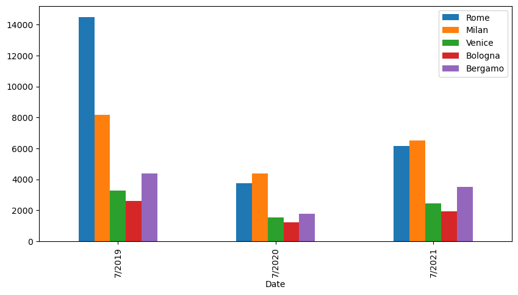

```python
df0.plot(x='Date', y=['Rome', 'Milan', 'Venice', 'Bologna', 'Bergamo'], kind="bar", figsize=(10, 5))
print()
```

```python
fig = px.bar(df0, x='Date', y=['Date', 'Rome', 'Milan', 'Venice', 'Bologna', 'Bergamo'],barmode='group',
             title='Number of flights per airpot and year')
fig.update_yaxes(title_text='Number of flights')

fig.show()
```

[output not shown]

```python
# Total flights per year in the five main airports

#2019
total_2019 = len(datarome2019) + len(datamilan2019) + len(datavenice2019) + len(databologna2019) + len(databergamo2019)
print(f'The total number of flights for the 5 airports in 2019 is: {total_2019}')

#2020
total_2020 = len(datarome2020) + len(datamilan2020) + len(datavenice2020) + len(databologna2020) + len(databergamo2020)
print(f'The total number of flights for the 5 airports in 2020 is: {total_2020}')

#2021
total_2021 = len(datarome2021) + len(datamilan2021) + len(datavenice2021) + len(databologna2021) + len(databergamo2021)
print(f'The total number of flights for the 5 airports in 2021 is: {total_2021}')
```

```
The total number of flights for the 5 airports in 2019 is: 32917
The total number of flights for the 5 airports in 2020 is: 12618
The total number of flights for the 5 airports in 2021 is: 20479
```

```python
#Save the data in an array

totalperyear = [total_2019, total_2020, total_2021]
dataflights = [[date[0], totalperyear[0]], [date[1], totalperyear[1]], [date[2], totalperyear[2]]]

df = pd.DataFrame(dataflights, columns=['Date', 'Number of flights'])
df.head()
```

|  | Date | Number of flights |
| --- | --- | --- |
| 0 | 7/2019 | 32917 |
| 1 | 7/2020 | 12618 |
| 2 | 7/2021 | 20479 |

```python
# Total flights in the 5 main airports of Italy (month 7 2019 to 2021)

fig = px.bar(df, x='Date', y='Number of flights',
             title='Total flights in the five main airports of Italy')

fig.update_traces(text=df['Number of flights'])
fig.show()
```

[output not shown]

We can obserb a pattern that is repeated on each airport data. During 2020, the number of flights decreased, and in 2021 there was a partial recovery.

COVID data:

We can notice already that there was a decrease in flight numbers from 2019 to 2020, and a partial recovery from 2020 to 2021

```python
dataCOVID = pd.read_csv('italy_vaccination.csv')
dataCOVID.head()
```

|  | Unnamed: 0 | total_cases | total_vaccinations | date | new_vaccinations_smoothed_per_million | new_cases_per_million | new_cases | total_deaths | new_deaths_per_million | new_deaths |
| --- | --- | --- | --- | --- | --- | --- | --- | --- | --- | --- |
| 0 | 98722 | 2.0 | NaN | 2020-01-31 | NaN | 0.034 | 2.0 | NaN | NaN | NaN |
| 1 | 98723 | 2.0 | NaN | 2020-02-01 | NaN | 0.000 | 0.0 | NaN | NaN | NaN |
| 2 | 98724 | 2.0 | NaN | 2020-02-02 | NaN | 0.000 | 0.0 | NaN | NaN | NaN |
| 3 | 98725 | 2.0 | NaN | 2020-02-03 | NaN | 0.000 | 0.0 | NaN | NaN | NaN |
| 4 | 98726 | 2.0 | NaN | 2020-02-04 | NaN | 0.000 | 0.0 | NaN | NaN | NaN |

```python
dataCOVID_072020 = dataCOVID.loc[152:182]
dataCOVID_072020.head()
```

|  | Unnamed: 0 | total_cases | total_vaccinations | date | new_vaccinations_smoothed_per_million | new_cases_per_million | new_cases | total_deaths | new_deaths_per_million | new_deaths |
| --- | --- | --- | --- | --- | --- | --- | --- | --- | --- | --- |
| 152 | 98874 | 240760.0 | NaN | 2020-07-01 | NaN | 3.072 | 182.0 | 34788.0 | 0.354 | 21.0 |
| 153 | 98875 | 240961.0 | NaN | 2020-07-02 | NaN | 3.393 | 201.0 | 34818.0 | 0.506 | 30.0 |
| 154 | 98876 | 241184.0 | NaN | 2020-07-03 | NaN | 3.764 | 223.0 | 34833.0 | 0.253 | 15.0 |
| 155 | 98877 | 241419.0 | NaN | 2020-07-04 | NaN | 3.967 | 235.0 | 34854.0 | 0.354 | 21.0 |
| 156 | 98878 | 241611.0 | NaN | 2020-07-05 | NaN | 3.241 | 192.0 | 34861.0 | 0.118 | 7.0 |

```python
covidcases_072020 = dataCOVID_072020['new_cases'].sum()
print(f'The total number of new cases during July 2020 was {covidcases_072020}')
```

```
The total number of new cases during July 2020 was 6959.0
```

```python
dataCOVID_072021 = dataCOVID.loc[517:547]
dataCOVID_072021.head()
```

|  | Unnamed: 0 | total_cases | total_vaccinations | date | new_vaccinations_smoothed_per_million | new_cases_per_million | new_cases | total_deaths | new_deaths_per_million | new_deaths |
| --- | --- | --- | --- | --- | --- | --- | --- | --- | --- | --- |
| 517 | 99239 | 4260788.0 | 52733773.0 | 2021-07-01 | 9345.0 | 14.838 | 879.0 | 127587.0 | 0.354 | 21.0 |
| 518 | 99240 | 4261582.0 | 53290240.0 | 2021-07-02 | 9195.0 | 13.403 | 794.0 | 127615.0 | 0.473 | 28.0 |
| 519 | 99241 | 4262511.0 | 53817991.0 | 2021-07-03 | 9128.0 | 15.682 | 929.0 | 127637.0 | 0.371 | 22.0 |
| 520 | 99242 | 4263317.0 | 54232915.0 | 2021-07-04 | 9087.0 | 13.606 | 806.0 | 127649.0 | 0.203 | 12.0 |
| 521 | 99243 | 4263797.0 | 54774452.0 | 2021-07-05 | 9042.0 | 8.103 | 480.0 | 127680.0 | 0.523 | 31.0 |

```python
covidcases_072021 = dataCOVID_072021['new_cases'].sum()
print(f'The total number of new cases during July 2021 was {covidcases_072021}')
```

```
The total number of new cases during July 2021 was 90119.0
```

```python
print(f'There were {covidcases_072020} new cases during July 2020, and {covidcases_072021} during 2021')
print(f'During July 2021, there were {covidcases_072021-covidcases_072021} more cases than in the same period of 2020')
```

```
There were 6959.0 new cases during July 2020, and 90119.0 during 2021
During July 2021, there were 0.0 more cases than in the same period of 2020
```

```python
#Save the data in an array
date = ['7/2019', '7/2020', '7/2021']
totalperyear = [total_2019, total_2020, total_2021]
caseseachyear = [0, covidcases_072020, covidcases_072021]
dataflights = [[date[0], totalperyear[0], caseseachyear[0]], [date[1], totalperyear[1], caseseachyear[1]], [date[2], totalperyear[2], caseseachyear[2]]]

df1 = pd.DataFrame(dataflights, columns=['Date', 'Number of flights', 'Covid cases'])
df1.head()
```

|  | Date | Number of flights | Covid cases |
| --- | --- | --- | --- |
| 0 | 7/2019 | 32917 | 0.0 |
| 1 | 7/2020 | 12618 | 6959.0 |
| 2 | 7/2021 | 20479 | 90119.0 |

```python
fig = px.bar(df1, x='Date', y=['Number of flights', 'Covid cases'],barmode='group',
             title='Number of flights and covid cases')

fig.update_traces(text=df1['Number of flights'])
fig.update_yaxes(title_text='Quantities')
fig.update_yaxes(title_text='Year (month 7)')

fig.show()
```

[output not shown]

# But why if there were more cases in 2021 than in 2020, the flight industry recovered partially?

```python
datavaccines = pd.read_csv('italy_vaccination.csv')
datavaccines.head()
```

|  | Unnamed: 0 | total_cases | total_vaccinations | date | new_vaccinations_smoothed_per_million | new_cases_per_million | new_cases | total_deaths | new_deaths_per_million | new_deaths |
| --- | --- | --- | --- | --- | --- | --- | --- | --- | --- | --- |
| 0 | 98722 | 2.0 | NaN | 2020-01-31 | NaN | 0.034 | 2.0 | NaN | NaN | NaN |
| 1 | 98723 | 2.0 | NaN | 2020-02-01 | NaN | 0.000 | 0.0 | NaN | NaN | NaN |
| 2 | 98724 | 2.0 | NaN | 2020-02-02 | NaN | 0.000 | 0.0 | NaN | NaN | NaN |
| 3 | 98725 | 2.0 | NaN | 2020-02-03 | NaN | 0.000 | 0.0 | NaN | NaN | NaN |
| 4 | 98726 | 2.0 | NaN | 2020-02-04 | NaN | 0.000 | 0.0 | NaN | NaN | NaN |

```python
vaccination2020 = datavaccines.loc[152:182]
vaccination2020.head()

vaccinations2020 = vaccination2020['new_vaccinations_smoothed_per_million'].sum()
print(vaccinations2020)
print(f'No vaccination during July 2020')
```

```
0.0
No vaccination during July 2020
```

```python
vaccination2021 = datavaccines.loc[517:547]
# vaccination2021.head()
```

```python
Population_italy_2021 = 60370000
```

```python
totalvaccinatedpeople072021 = datavaccines['total_vaccinations'].loc[547]

# print(totalvaccinatedpeople072021)

print(f'While during July 2020 there was no people vaccinated, in July 2021 this number changed to \
{totalvaccinatedpeople072021} people')
```

```
While during July 2020 there was no people vaccinated, in July 2021 this number changed to 68888006.0 people
```

And what about mortality:

```python
mortality2020 = datavaccines.loc[152:182]
# mortality2020.head()
```

```python
deaths072020 = mortality2020['new_deaths'].sum()
print(deaths072020)
```

```
374.0
```

```python
mortality2021 = datavaccines.loc[517:547]
# mortality2021.head()
```

```python
deaths072021 = mortality2021['new_deaths'].sum()
print(deaths072021)
```

```
497.0
```

```python
# Relation between new cases and deaths

relation2020 = deaths072020 / covidcases_072020

print(f'The relation is {relation2020:.3f}')

relation2021 = deaths072021 / covidcases_072021

print(f'The relation is {relation2021:.3f}')
```

```
The relation is 0.054
The relation is 0.006
```

2- The number of infections during July 2021 was higher than durnig July 2020

3 - Still, there was a partiall recovery in number of flights, even tough the number of people infected was higher

4 - The rate between infected peope and deceases is way higher during 2020 than during 2021.

The partial recovery in flight numbers during 2021 happened as a consequence of vaccination and the decrease in mortality of COVID

```python
# To sum up

# Flights

print(f'-The total number of flights for the 5 airports in 2019 is: {total_2019}')
print(f'-The total number of flights for the 5 airports in 2020 is: {total_2020}')
print(f'-The total number of flights for the 5 airports in 2021 is: {total_2021}')
print()


# Cases

print(f'-The total number of new cases during July 2020 was {covidcases_072020}')
print(f'-The total number of new cases during July 2021 was {covidcases_072021}')
print()

# Vaccination

print(f'-During July 2020 no people got vaccinated')
print(f'-During July 2021 {totalvaccinatedpeople072021} people got vaccinated')
print()

# Deceases

print(f'-There were {deaths072020} deceases during July 2020')
print(f'-There were {deaths072021} deceases during July 2021')
print()

# Rate infections - deceases

print(f'-The relation between deaths and covid cases during July 2020 is {relation2020:.3f}')
print(f'-The relation between deaths and covid cases during July 2021 is {relation2021:.3f}')
```

```
-The total number of flights for the 5 airports in 2019 is: 32917
-The total number of flights for the 5 airports in 2020 is: 12618
-The total number of flights for the 5 airports in 2021 is: 20479

-The total number of new cases during July 2020 was 6959.0
-The total number of new cases during July 2021 was 90119.0

-During July 2020 no people got vaccinated
-During July 2021 68888006.0 people got vaccinated

-There were 374.0 deceases during July 2020
-There were 497.0 deceases during July 2021

-The relation between deaths and covid cases during July 2020 is 0.054
-The relation between deaths and covid cases during July 2021 is 0.006
```

```python
deceaseswrate2020= deaths072020 * relation2020
deceaseswrate2021= deaths072021 * relation2021;
Deceases = [0, deceaseswrate2020, deceaseswrate2021]

print(Deceases)
```

```
[0, 20.10001436988073, 2.740920338663323]
```

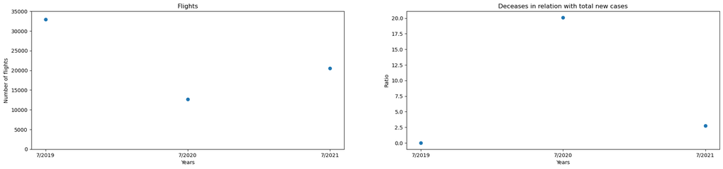

```python
plt.subplot(121)
plt.plot(date, totalperyear, 'o')
plt.title('Flights')
plt.xlabel('Years')
plt.ylabel('Number of flights')
plt.yticks(np.arange(0,40000,5000))

plt.subplot(122)
plt.plot(date, Deceases, 'o')
plt.title('Deceases in relation with total new cases')
plt.xlabel('Years')
plt.ylabel('Ratio')

plt.subplots_adjust(right=3)
```

It is clear that the higher the deceases ratio, the lower the number of flights, which explains the partial recovery during 2021